# Module 9: Support Vector Machines

TMA4268 Statistical Learning V2023

Stefanie Muff, Department of Mathematical Sciences, NTNU

March 13 and 16, 2023

# Acknowledgements

- The course was originally developed by Mette Langaas (original material: https://github.com/mettelang/StatisticalLearningSpring2019). Mette did a fantastic job and I am very thankful that I was allowed to modify and use her material.
- Some of the figures and slides in this presentation are taken (or are inspired) from James et al. (2013).

# Introduction

## Learning material for this module

- James et al (2021): An Introduction to Statistical Learning. Chapter 9.
- All the material presented on these module slides and in class.
- Check also the “Further reading” slide at the end of these module slides.

## What will you learn?

You will get to know

$~$

- Maximal margin classifier
- Support vector classifier
- Support vector machines
- Extensions
- Comparisons

$~$

and learn how to apply all that.

# Support Vector Machines

$~$

$~$

If this is not possible, we soften our requirement in two ways:

- We soften what we mean by “separates”.
- We enrich and enlarge the feature space such that we can do a separation

$~$

Support Vector Machines (SVMs) are a computer science method, not really a statistical method (no probabilities involved).

## Motivating example

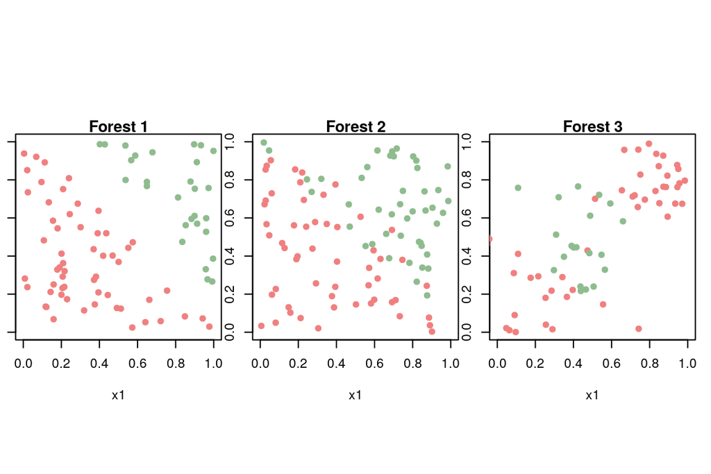

- You want to build one continuous fence to separate the two tree types in each of the three study areas. **Where should you build the fence?**

Three cases:

- Forest 1 seems easy: The orange and green points are clearly separated and the fence can be built anywhere inside the band that separates them. However, there are infinitely many solutions.
- Forest 2 is a bit more complicated: A linear fence still seems like a good idea, but in this case the two tree types cannot be perfectly separated. You have to allow some errors.
- Forest 3 is the most complex: It is not possible to separate the two tree types by a straight line without getting a large number of misclassifications. Here, a circular fence around the pine trees seems like a reasonable choice.

Forest 1 illustrates the problem of finding an **optimal separating hyperplane** for a dataset.

Topic: **Maximal Margin hyperplanes**

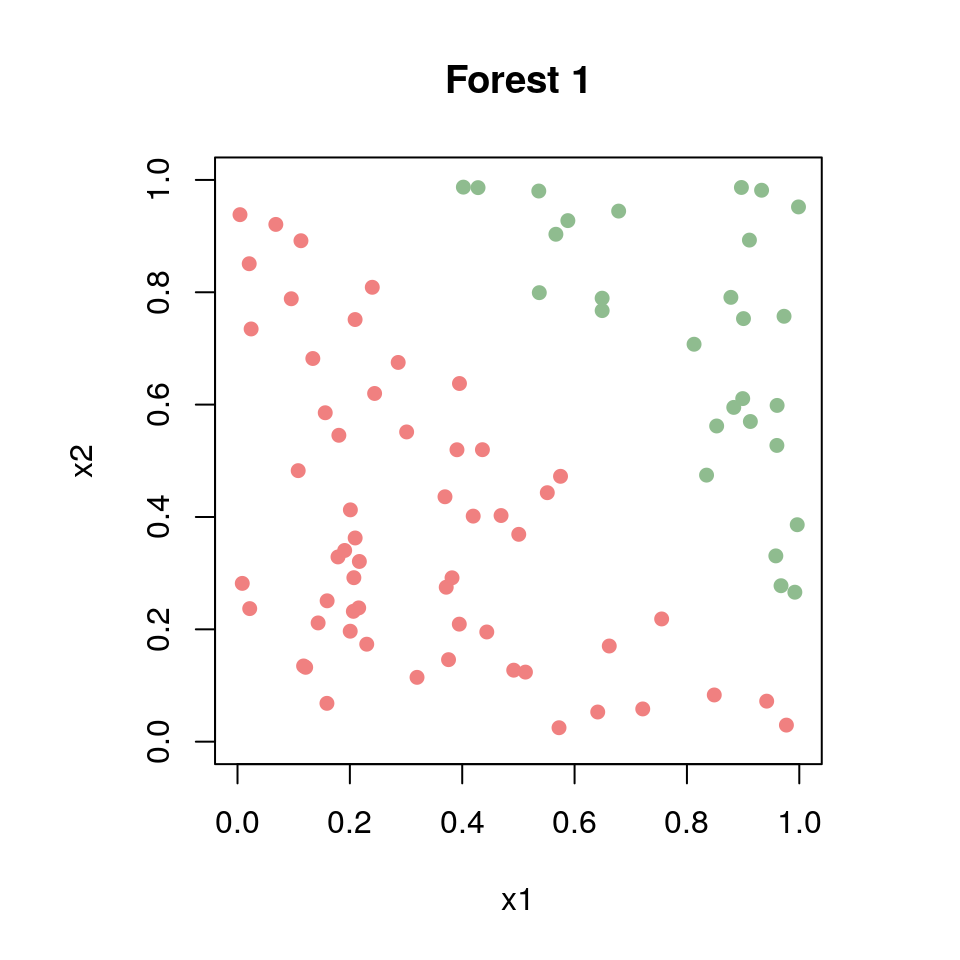

You are also going to learn how you can find an optimal separating hyperplane when your data cannot be perfectly separated by a straight line.

Topic: **Support Vector Classifier** or **Soft Margin Classifier**

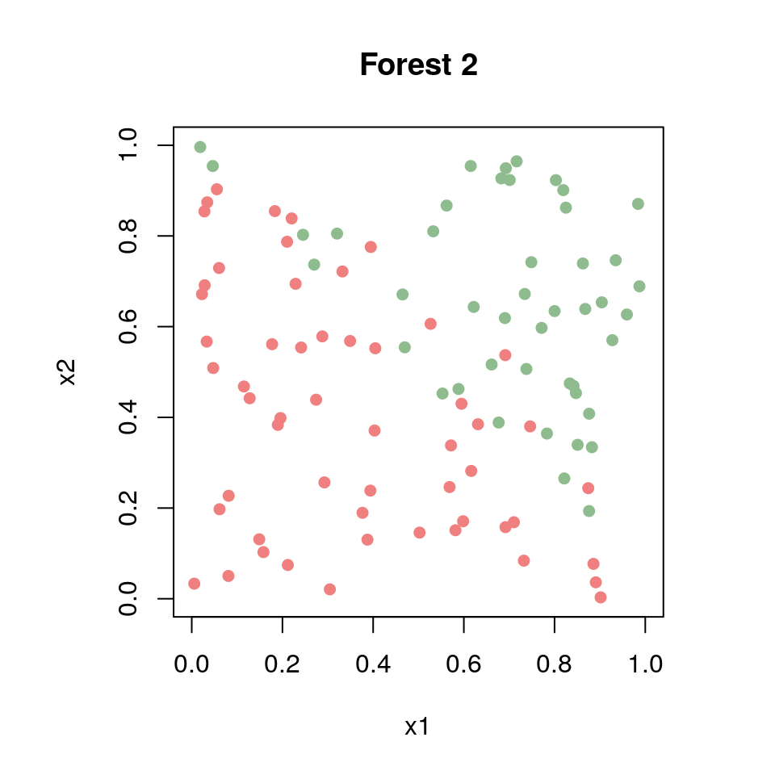

The Support vector classifier can be generalised to an approach that produces non-linear decision boundaries.

Topic: **Support Vector Machines** (SVMs)

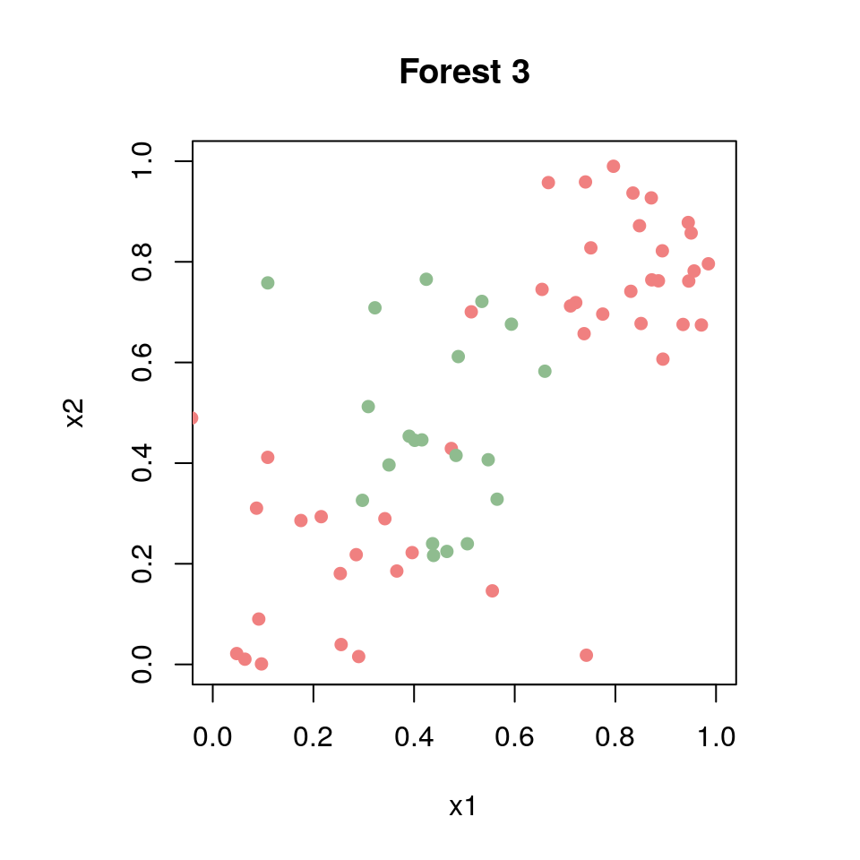

Why are we interested in an optimal hyperplane or a separating curve?

$\rightarrow$ We want to use it for classification.

- In our example: Is it likely that a random seed found at location $(0.8,0.4)$ becomes a redwood or a pine tree given the observed data?
- Classification of a new observation based on which side of the decision boundary it falls into.

**Note**: In this module we look at **binary classification**, but extensions to more than two classes are briefly mentioned.

- We will use the three forest examples throughout this module.
- The two covaraites ($x_1$, $x_2$) are the coordinates of the trees.
- The response is either $pine$ ($y=1$) or $redwood$ ($y=-1$).
- **Goal**: to make a classifier for random seeds that we find on the ground for each of the three forests. The locations of the seeds are shown in the figure below (black circles).
- The point patterns of the known locations can be thought of as the training set.
- The point pattern generated by the black circles can be thought of as the test set.

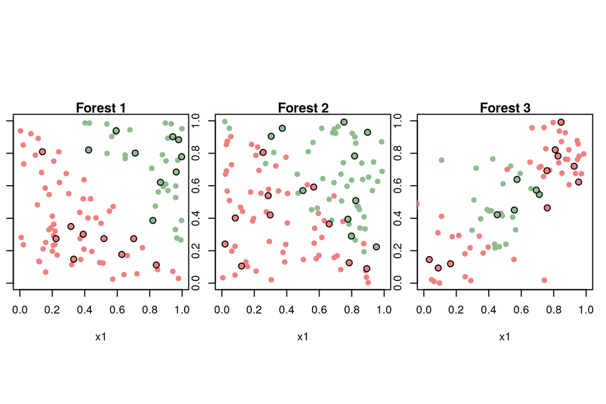

# Maximal Margin Classifier

## Hyperplane

A **hyperplane** in $p$ dimensions is defined as

$$\beta_0+\beta_1 X_1 + \beta_2 X_2
+...+\beta_p X_p=\beta_0+{\boldsymbol X}^T {\boldsymbol
\beta}=0.$$
and is a $p-1$ dimensional subspace of $\mathbb{R}^p$.

**Recap**:

- If a point ${\boldsymbol x}=(x_1,x_2,...,x_p)^T$ satisfies the above equation, it lies on the hyperplane.
- If $\beta_0=0$ the hyperplane goes through the origin.
- The vector ${\boldsymbol \beta}=(\beta_1, \ldots, \beta_p)$ (not including $\beta_0$) is called the normal vector and points in the direction orthogonal to the hyperplane.

If a point ${\boldsymbol x}$ satisfies

- $\beta_0+ {\boldsymbol \beta}^\top {\boldsymbol x}>0$ it lies on one side of the hyperplane.
- $\beta_0+{\boldsymbol \beta}^\top {\boldsymbol x}<0$ it lies on the opposite side of the hyperplane.
- $\beta_0+{\boldsymbol \beta}^\top {\boldsymbol x}=0$ it lies on the hyperplane (by definition!).
- The signed distance $d$ of any point $\boldsymbol x$ to the hyperplane is given by
  $$d=\frac{1}{||{\boldsymbol\beta}||} (\beta_0 +
  {\boldsymbol \beta}^\top {\boldsymbol x} )\ ,$$
  where $||{\boldsymbol\beta}||^2 = \sum_{j=1}^p \beta_j^2=1$ is the (squared) length of $\boldsymbol \beta$ (Euclidian norm), see also [here](https://en.wikipedia.org/wiki/Distance_from_a_point_to_a_plane).
- See board for a graphical description.

## Assumptions

$~$

- Assume that we have $n$ training observations with $p$ predictors
  $${\boldsymbol x}_1=\left(
  \begin{array}{c}
  x_{11} \\
  \vdots \\
  x_{1p}
  \end{array}
  \right), \ldots, {\boldsymbol x}_n=\left(
  \begin{array}{c}
  x_{n1} \\
  \vdots \\
  x_{np}
  \end{array}
  \right) \ .$$

$~$

- The responses $\boldsymbol{y}$ fall into two classes $y_1,...,y_n \in \{-1,1\}$.

$~$

- It is possible to separate the training observations perfectly according to their class.

## Possible hyperplanes (Forest 1)

Which is “best”?

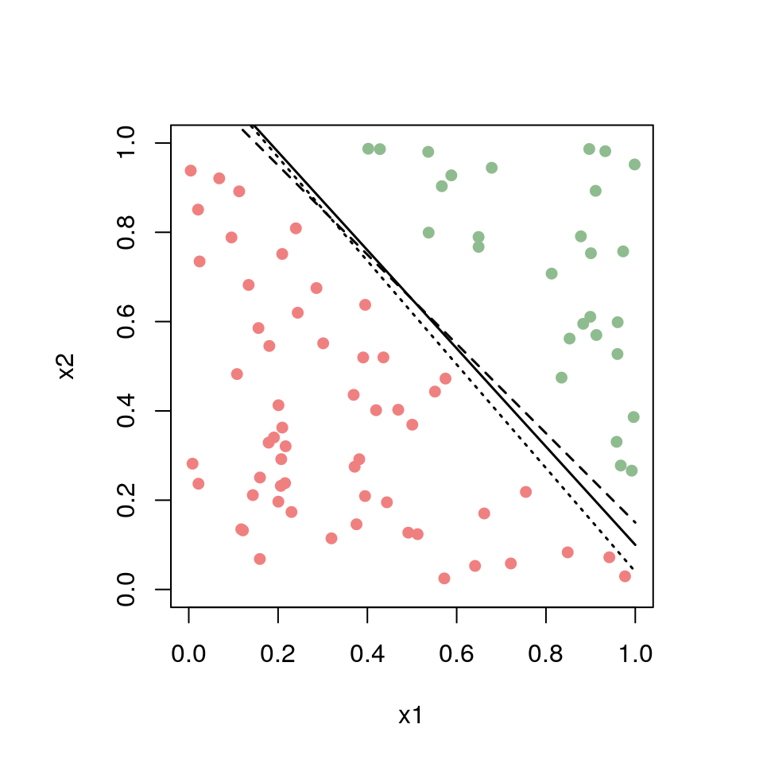

**Q:** How did we solve that problem earlier (e.g. in LDA, QDA, KNN,..)?

## Classification with a simple hyperplane

All three hyperplanes have the property that

$$\beta_0+\beta_1 x_{i1} + \beta_2 x_{i2}
=\beta_0+{\boldsymbol x}_i^T {\boldsymbol \beta}>0$$

if $y_i=1$ (green points) and

$$\beta_0+\beta_1 x_{i1} + \beta_2 x_{i2}
=\beta_0+{\boldsymbol x}_i^T {\boldsymbol \beta}<0$$

if $y_i=-1$ (orange points).

$~$

In brief:

$$y_i (\beta_0+{\boldsymbol x}_i^T
{\boldsymbol \beta})>0 \ .$$

Analogous for $p$ predictors: The class $y^*$ of a new observation ${\boldsymbol x}^*=(x_1^*,...,x_p^*)$ is assigned depending on the value $f({\boldsymbol x}^*)=\beta_0+\beta_1 x_1^* + \beta_2 x_{2}^*+...+\beta_p x_{p}^*.$

**Hyperplane classifier:**

$$y^* = \left\{ \begin{array}{ll}
1 \ , & \text{if } f({\boldsymbol x}^*) >0 \ ,\\
-1 \ , & \text{if } f({\boldsymbol x}^*) < 0 \ .
\end{array}\right.$$

$~$

Or

$$y^* f({\boldsymbol x}^*) > 0 \ .$$

## Which hyperplane is best?

- In general, if data are linearly separable, infinitely many possible separating hyperplanes exist.
- Natural choice: the **maximal margin hyperplane**, which maximises the distance from the training observations.

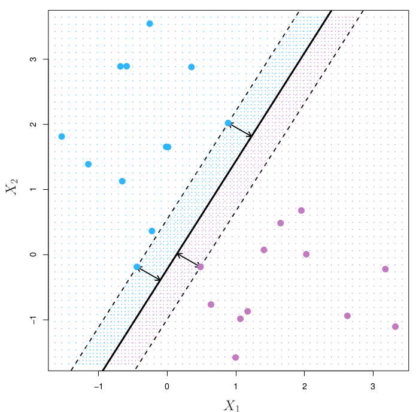

ISLR Figure 9.3

The process of finding the maximal margin hyperplane for a dataset with $p$ covariates and $n$ training observations can be formulated through the following **optimization problem**:

$$\mathrm{maximize}_{\beta_0,\beta_1,...,\beta_p} M$$
$$\text{subject to} \sum_{j=1}^p
\beta_j^2=1,$$
$$y_i(\beta_0+\beta_1
x_{i1}+\beta_2 x_{i2}+...+\beta_p x_{ip})\geq M \quad \forall
i=1,...,n$$
where $M$ is the width of the margin.

$~$

Observe:

- $y_i(\beta_0+{\boldsymbol x}^T {\boldsymbol \beta})$ is the (signed) distance from the $i$th point to the hyperplane defined by the $\beta$s.
- We want to find the hyperplane, where each observation is at least $M$ units away - on the correct side, where $M$ is as big as possible.
- In the ISLR Figure 9.3, the three equidistant point are called **support vectors**.
- It can be shown, see for example Hastie, Tibshirani, and Friedman (2009) Section 4.5.2 (*Optimal Separating Hyperplanes*), that the optimization problem can be reformulated using Lagrange multipliers (primal and dual problem) into a quadratic convex optimization problem that can be solved efficiently.

**Q**: But why do we need to solve the optimization problem, if the solution only depends on a few support vectors?

**A**:

## Questions

1. Is there any tuning parameters that needs to be chosen?
2. Look at the figure below. What could be the problem with the (maximal margin) hyperplane idea?

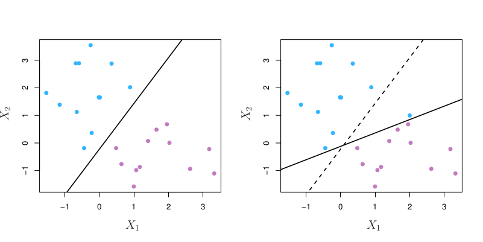

ISLR Figure 9.5

- If one of the support vectors changes its position, the whole hyperplane will move.
- This is a property of the maximal margin hyperplane: It only depends on the support vectors, and *not on the other observations*.

# Support Vector Classifiers

For some data sets a separating hyperplane does not exist, the data set is *non-separable*. What then? Forest 2:

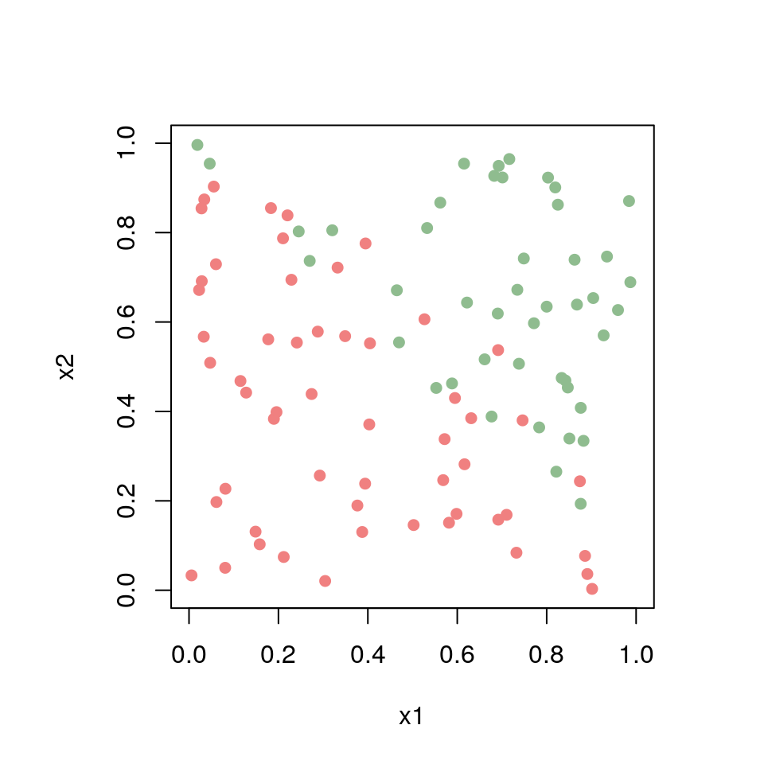

It is still possible to construct a hyperplane and use it for classification, but then we have to *allow some misclassification* in the training data.

- In some situations allowing for some misclassifications makes the class boundaries more robust to future observations (avoid overfitting).
- Even when the data are linearly separable, the separating hyperplane might not be the “best” hyperplane for us in terms of robustness.
- We relax the maximal margin classifier to allow for a *soft margin classifier* (=support vector classifier).

## Optimization problem

To obtain a **support vector classifier** we relax the conditions that we had for the maximal margin hyperplane by allowing for a “budget” $C$ of misclassifications:

$$\mathrm{maximize}_{\beta_0,\beta_1,...,\beta_p} M$$

$$\text{subject to} \sum_{j=1}^p
\beta_j^2=1,$$
$$y_i(\beta_0+\beta_1
x_{i1}+\beta_2 x_{i2}+...+\beta_p x_{ip})\geq M(1-\epsilon_i)
\quad \forall i=1,...,n.$$
$$\epsilon_i\geq 0, \quad \sum_{i=1}^n \epsilon_i
\leq C.$$

Figure 19.3 in Efron and Hastie (2016) gives a nice graphical representation of the soft margin classifier idea, where the violations (estimates of $\epsilon_i$) are shown in green:

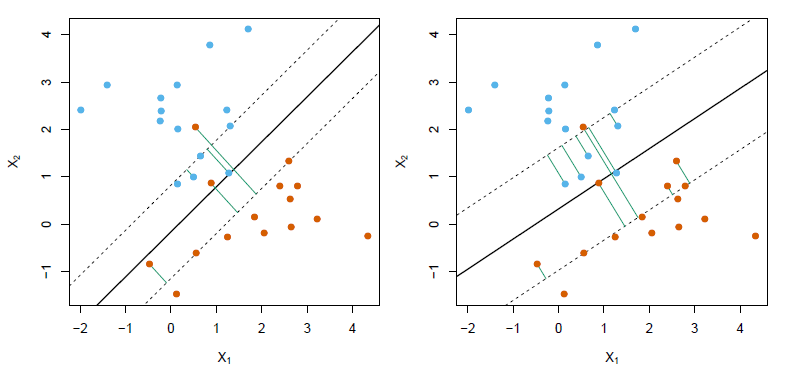

casi Figure 19.3

**Classification rule:** We classify a test observation ${\boldsymbol x}^*$ based on the sign of $f({\boldsymbol x}^*)=\beta_0+\beta_1 x_1^*+...+\beta_p x_p^*$ as before:

- If $f({\boldsymbol x}^*)<0$ then $y^*=-1$.
- If $f({\boldsymbol x}^*)>0$ then $y^*=1$.

More on solving the optimization problem: Hastie, Tibshirani, and Friedman (2009) Section 12.2.1 (primal and dual Lagrange problem, quadratic convex problem).

## Questions (Poll)

www.menti.com; 5260 7837

1. Should the variables be standardized before used with this method?
2. The support vector classifier only depends on the observations that violate the margin. How does $C$ affect the width of the margin?
3. How does the tuning parameter $C$ affect the bias-variance trade-off of the method?

**A:**

### Role of the tuning parameter $C$

ISLR Figure 9.7: From large $C$ (top left) to small $C$ (bottom right). As C decreases the tolerance for observations being on the wrong side of the margin decreases and the margin narrows.

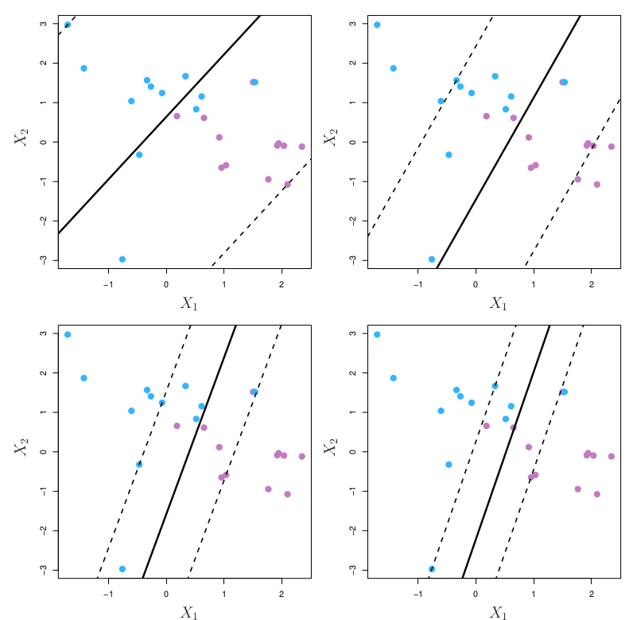

ISLR Figure 9.7: Top left=large C, smaller top right, bottom left and bottom right. As C decreases the tolerance for observations being on the wrong side of the margin decreases, and the margin narrows.

## Example

We will now find a support vector classifier for the second training dataset (`forest2`) and use this to classify the observations in the second test set (`seeds2`).

- There are $100$ observations of trees: 45 pines ($y_i=1$) and 55 redwood trees ($y_i=-1$).
- In the test set there are 20 seeds: 10 pine seeds and 10 redwood seeds.

The function `svm` in the package `e1071` is used to find the maximal margin hyperplane. The response needs to be coded as a factor variable, and the data set has to be stored as a dataframe.

```r
library(e1071)
forest2 = read.table(file = "forest2.txt")
seeds2 = read.table(file = "seeds2.txt")
train2 = data.frame(x = forest2[, 1:2], y = as.factor(forest2[, 3]))
test2 = data.frame(x = seeds2[, 1:2], y = as.factor(seeds2[, 3]))
```

The `svm` function uses a slightly different formulation than what we introduced above.

We first try with `cost=1`. We set `kernel='linear'` as we are interested in a linear decision boundary. `scale=TRUE` scales the predictors to have mean 0 and standard deviation 1. We choose `scale=FALSE` (no scaling).

$~$

```r
svmfit_linear1 = svm(y ~ ., data = train2, kernel = "linear", cost = 1,
    scale = FALSE)
```

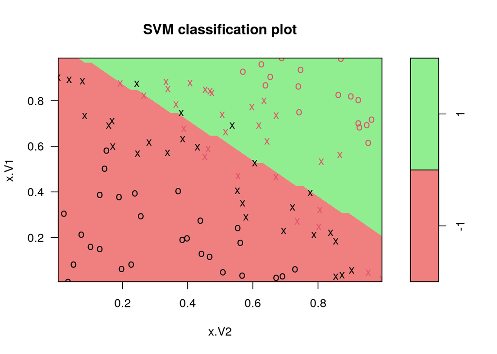

```r
plot(svmfit_linear1, train2, col = c("lightcoral", "lightgreen"))
```

(Note: The decision boundary looks a bit strange, and $x_1$ is plotted on the (usual) $y$-axis and $x_2$ on the $x$-axis. Both problems are due to implementation, nothing for us to worry.)

```r
summary(svmfit_linear1)
```

```
##
## Call:
## svm(formula = y ~ ., data = train2, kernel = "linear", cost = 1,
##     scale = FALSE)
##
##
## Parameters:
##    SVM-Type:  C-classification
##  SVM-Kernel:  linear
##        cost:  1
##
## Number of Support Vectors:  56
##
##  ( 28 28 )
##
##
## Number of Classes:  2
##
## Levels:
##  -1 1
```

**Observations**

- The crosses in the plot indicate the support vectors, whose index can be obtained from

```r
svmfit_linear1$index  #support vectors id in data set
```

```
##  [1]  1  2  4  6  9 10 16 21 26 27 28 40 44 53 55 57 58 65 67 72 76 77 80 81 87
## [26] 91 92 98  5  8 11 13 18 19 20 23 24 25 34 36 39 41 42 47 48 59 61 62 70 71
## [51] 75 78 88 93 95 96
```

$~$

- With `cost=1`, we have 56 support vectors, 28 in each class.
- All other data points are shown as circles.
- However, no explicit output for the linear decision boundary, and no margin width is given by `svm()`. Want to see how to find this? See the recommended exercises.

Next, we set `cost=100`:

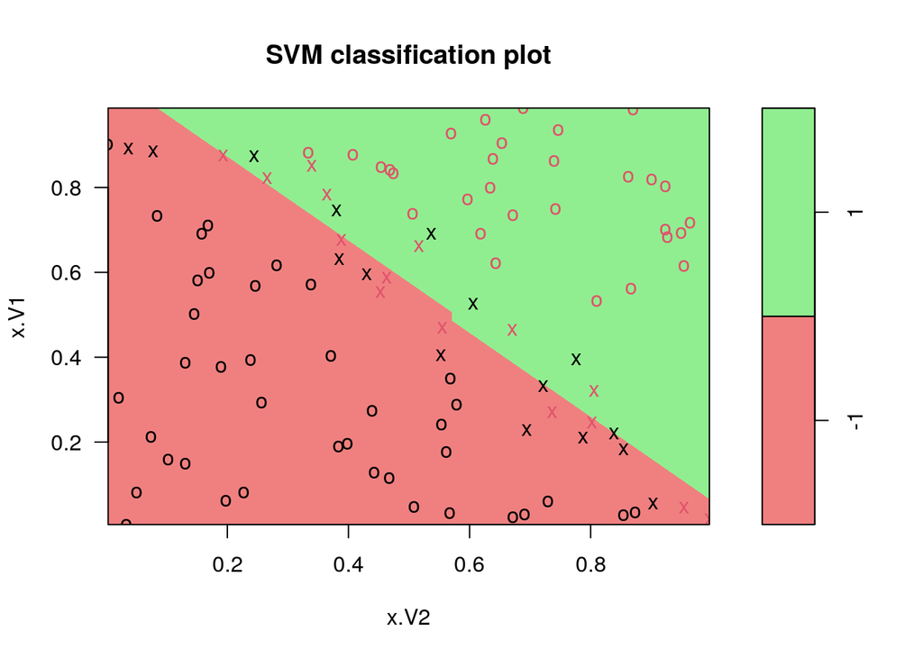

```r
svmfit_linear2 = svm(y ~ ., data = train2, kernel = "linear", cost = 100,
    scale = FALSE)
plot(svmfit_linear2, train2, col = c("lightcoral", "lightgreen"))
```

```r
summary(svmfit_linear2)
```

```
##
## Call:
## svm(formula = y ~ ., data = train2, kernel = "linear", cost = 100,
##     scale = FALSE)
##
##
## Parameters:
##    SVM-Type:  C-classification
##  SVM-Kernel:  linear
##        cost:  100
##
## Number of Support Vectors:  31
##
##  ( 15 16 )
##
##
## Number of Classes:  2
##
## Levels:
##  -1 1
```

Thus with `cost=100` we have 31 support vectors. The width of the margin is decreased.

### Cross-validation to find an optimal `cost`

The `cost` is a tuning parameter. By using the `tune()` function we can perform 10-fold cross-validation and find the cost-parameter that gives the lowest cross-validation error:

```r
set.seed(1)
CV_linear = tune(svm, y ~ ., data = train2, kernel = "linear", ranges = list(cost = c(0.001,
    0.01, 0.1, 1, 5, 10, 50)))
summary(CV_linear)
```

```
##
## Parameter tuning of 'svm':
##
## - sampling method: 10-fold cross validation
##
## - best parameters:
##  cost
##     5
##
## - best performance: 0.14
##
## - Detailed performance results:
##    cost error dispersion
## 1 1e-03  0.45 0.10801234
## 2 1e-02  0.23 0.12516656
## 3 1e-01  0.16 0.11737878
## 4 1e+00  0.15 0.10801234
## 5 5e+00  0.14 0.10749677
## 6 1e+01  0.15 0.09718253
## 7 5e+01  0.15 0.09718253
```

According to the `tune()` function we should set the cost parameter to 5. The function also stores the best model obtained and we can access it as follows:

```r
bestmod_linear = CV_linear$best.model
```

Next, we want to predict the class label of the seeds in the test set. We use the `predict` function and make a confusion table:

```r
ypred_linear = predict(bestmod_linear, test2)
table(predict = ypred_linear, truth = test2[, 3])
```

```
##        truth
## predict -1  1
##      -1  8  0
##      1   2 10
```

Thus two of the seeds are misclassified, the other 18 are ok.

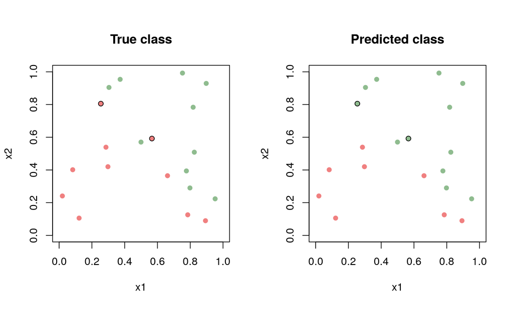

The two misclassified observations are marked with a black circle.

# Support Vector Machines

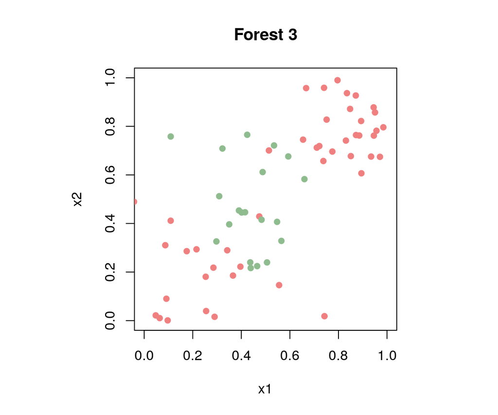

## Expanding the feature space

- Recall from Module 7: We could fit non-linear regression curves by using a polynomial basis. This was a **linear regression in the transformed variables**, but non-linear in the original variables.
- **Idea**: Find a linear boundary in that high-dimensional space using
  - higher-order terms $X_i^k$
  - interaction terms $X_i X_{i'}$
  - other functions of $X_i$.
- This leads to a non-linear boundary in the original space.
- **Example**:
  $$\beta_0 +
  \beta_1 X_1 + \beta_2 X_2 + \beta_3 X_1X_2 + \beta_4 X_1^2 + \beta_5
  X_2^2 =0 \ .$$

### Example

(ISRL Figure 9.9)

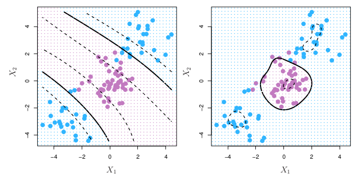

ISLR Figure 9.9

- **Left**: expanding feature space to include cubic polynomials ($x_1,x_2,x_1x_2,x_1^2,x_2^2,x_1^2x_2,x_1x_2^2x_1^3,x_2^3$, 9 parameters to estimate in addition to intercept), and also observe the margins (interpretation?).
- **Right**: radial basis function kernel - wait a bit.

### Problems and better ideas

$~$

- Computation using polynomials quickly becomes unmanageable.

$~$

- Higher-order polynomials become very wiggly and wild.

$~$

$~$

## Inner products

- Remember the optimisation problem of finding the support vector classifier hyperplane. We have *not* explained how to solve the problem because this is outside the scope of this course.
- But we said that
  $$\hat{\beta}=
  \sum_{i\in \mathcal{S}} \hat\alpha_i x_i$$
  for a support set $\mathcal{S}$.
- Thus the solution function $\hat{f}$ to the support vector classifier problem at a new observation ${\boldsymbol x}$, can be expressed as
  $$\begin{align*}
  \hat{f}(x) & = \hat{\beta}_0 + x^\top \hat\beta \\
  & = \hat\beta_0 + \sum_{i \in \mathcal{S}} \hat\alpha_i \langle
  x,x_i \rangle \ ,
  \end{align*}$$
  where $\alpha_i$ is some parameter and $i=1,...,n$.
- This implies that to estimate the parameters $\beta_0,\alpha_1,...,\alpha_n$ we only need to know the ${n \choose 2}$ inner products $\langle {\boldsymbol x}_i,{\boldsymbol x}_i' \rangle$ between all pair of training observations (and their correct class).
- Even better, $\alpha_i \neq 0$ for the support vectors $x_i$ ($i \in \mathcal{S}$), while $\alpha_i=0$ for all the rest.

$~$

This will bring us to another idea:

- All we need is to know to classify a new observations is the **similarity** to all the training observations, where similarity could be defined in any way.

**Q:** Find the support vectors

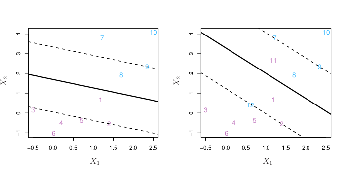

ISLR Figure 9.6

- **Q**: So why don’t we just directly only use the support vectors?
- **A**:

## Kernels

$~$

$~$

### The radial kernel

$~$

- A very popular choice is the *radial kernel*,
  $$K({\boldsymbol x}_i,{\boldsymbol x}_i')=\exp(-\gamma \sum_{j=1}^p
  (x_{ij}-x_{i'j})^2) \ ,$$
  where $\gamma$ is a positive constant (a tuning parameter).
- Interestingly, the radial kernel computes the inner product in a infinite dimensional feature space. But, this does not give overfitting because some of the dimensions are “squashed down”.
- We have the parameter $\gamma$ and the budget parameter $C$ to decide on.
- Connection to a multivariate normal density, where $\gamma \propto 1/\sigma^2$ ($\sigma^2$ variance in normal distribution). If $\gamma$ is small (similar to large variance in the normal distribution) the decision boundaries are smoother than for larger $\gamma$.
- The radial kernel is convenient if we want a circular decision boundary. See Figure 19.5 in Efron and Hastie (2016):

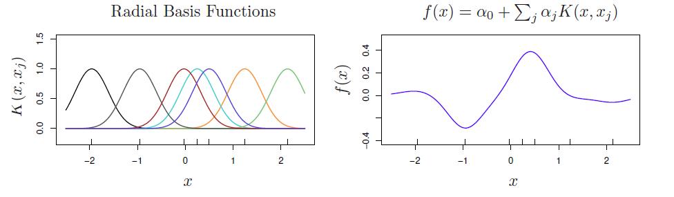

- $\gamma$ and our budget $C$ can be chosen by cross-validation.
- Remark: the mathematics behind this is based on *reproducing-kernel Hilbert spaces* (see page 384 of Efron and Hastie (2016) for a glimpse of the theory).

Study Figures 19.5 and 19.6 (page 383) in Efron and Hastie (2016) to see how the radial kernel can make smooth functions.

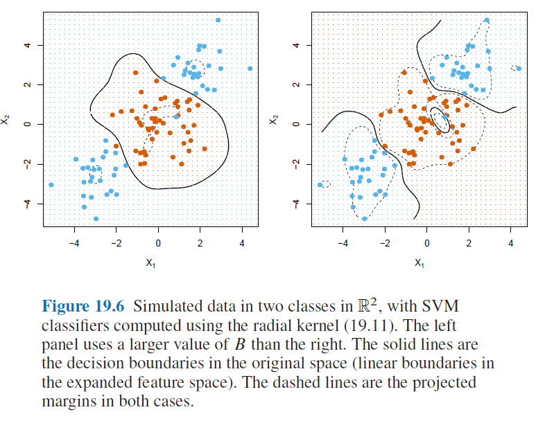

casi Figure 19.6

If you want to download the whole book you can do this here:

[Computer Age Statistical Inference](https://web.stanford.edu/~hastie/CASI_files/PDF/casi.pdf)

## Kernels and our optimization

We now merge our optimization problem (from our support vector classifier) with our kernel representation $f({\boldsymbol x})$ to get the

**Support Vector Machine (SVM)**

$$\mathrm{maximize}_{\beta_0,\alpha_1,...,\alpha_n,\epsilon_1,...,\epsilon_n,}
\quad M$$
$$y_i \cdot f({\boldsymbol
x}_i)\geq M(1-\epsilon_i) \quad \forall i=1,...,n \ ,$$
$$\epsilon_i\geq 0, \quad \sum_{i=1}^n \epsilon_i
\leq C \ ,$$

where
$$f({\boldsymbol x}_i)=\beta_0
+\sum_{l=1}^n \alpha_l K({\boldsymbol x}_i,{\boldsymbol x}_l) \
.$$

## Example: forest 3

To illustrate the SVM we use the third training dataset (`forest3`) and the third test set (`seeds3`). We use the `svm` function as before. However, we now set `kernel='radial'` as we want a non-linear decision boundary:

$~$

```r
library(e1071)
forest3 = read.table(file = "forest3.txt")
seeds3 = read.table(file = "seeds3.txt")
train3 = data.frame(x = forest3[, 1:2], y = as.factor(forest3[, 3]))
test3 = data.frame(x = seeds3[, 1:2], y = as.factor(seeds3[, 3]))
```

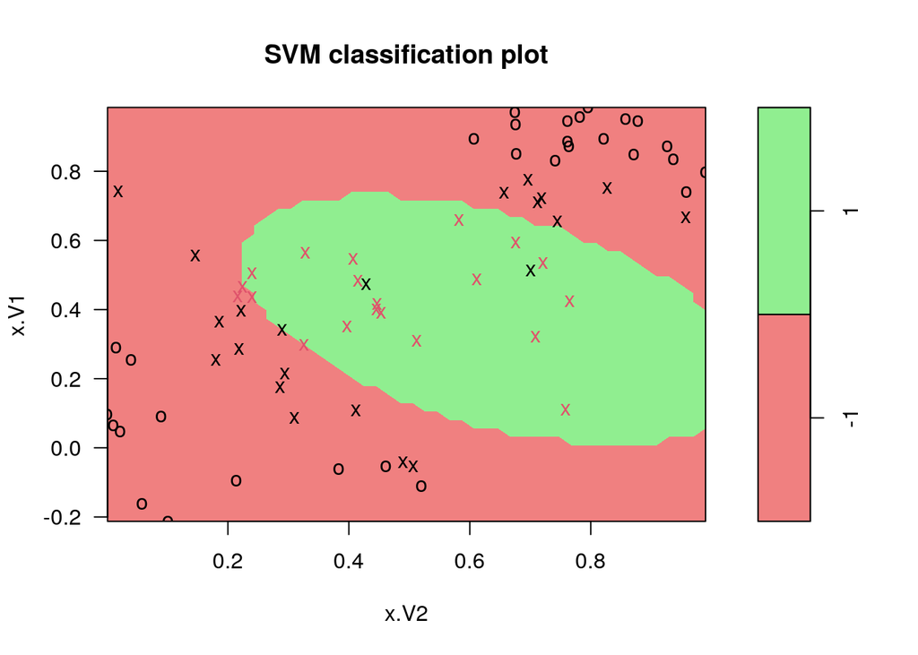

```r
svmfit_kernel1 = svm(y ~ ., data = train3, kernel = "radial", cost = 10,
    scale = FALSE)
plot(svmfit_kernel1, train3, col = c("lightcoral", "lightgreen"))
```

```r
summary(svmfit_kernel1)
```

```
##
## Call:
## svm(formula = y ~ ., data = train3, kernel = "radial", cost = 10,
##     scale = FALSE)
##
##
## Parameters:
##    SVM-Type:  C-classification
##  SVM-Kernel:  radial
##        cost:  10
##
## Number of Support Vectors:  42
##
##  ( 22 20 )
##
##
## Number of Classes:  2
##
## Levels:
##  -1 1
```

We could also try with a polynomial kernel with degree 4 as follows:

$~$

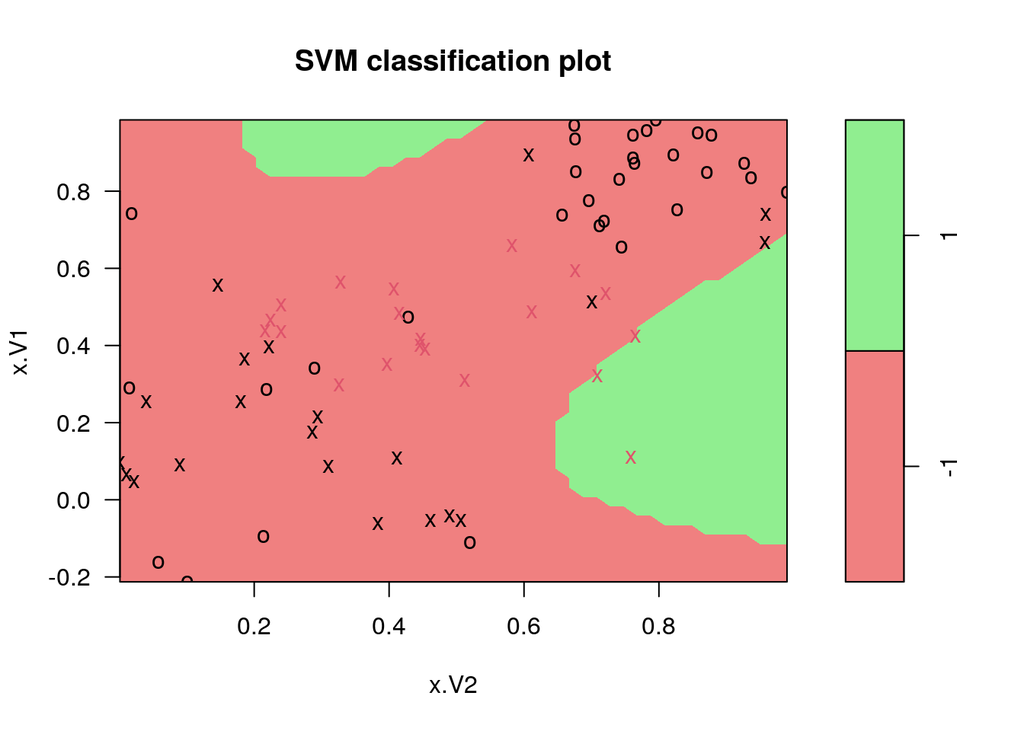

```r
svmfit_kernel2 = svm(y ~ ., data = train3, kernel = "polynomial", degree = 4,
    cost = 10000, scale = FALSE)
plot(svmfit_kernel2, train3, col = c("lightcoral", "lightgreen"))
```

```r
summary(svmfit_kernel2)
```

```
##
## Call:
## svm(formula = y ~ ., data = train3, kernel = "polynomial", degree = 4,
##     cost = 10000, scale = FALSE)
##
##
## Parameters:
##    SVM-Type:  C-classification
##  SVM-Kernel:  polynomial
##        cost:  10000
##      degree:  4
##      coef.0:  0
##
## Number of Support Vectors:  41
##
##  ( 21 20 )
##
##
## Number of Classes:  2
##
## Levels:
##  -1 1
```

For this dataset a radial kernel is a natural choice: A circular decision boundary seems like a good idea. Thus, we proceed with `kernel='radial'`, and use the `tune()` function to find (approximately) optimal tuning parameters $C$ and $\gamma$:

$~$

```r
set.seed(1)
CV_kernel = tune(svm, y ~ ., data = train3, kernel = "radial", ranges = list(cost = c(0.01,
    0.1, 1, 5, 10, 100, 1000), gamma = c(0.01, 0.1, 1, 10, 100)))
summary(CV_kernel)
```

```
##
## Parameter tuning of 'svm':
##
## - sampling method: 10-fold cross validation
##
## - best parameters:
##  cost gamma
##     5   0.1
##
## - best performance: 0.09642857
##
## - Detailed performance results:
##     cost gamma      error dispersion
## 1  1e-02 1e-02 0.27321429 0.14726580
## 2  1e-01 1e-02 0.27321429 0.14726580
```

[output cut: 33 more lines]

The optimal combination of parameters is $C=5$ and $\gamma=0.1$. Next, we predict the class label of the seeds in the test set using the optimal parameters, make a confusion table and plot the results:

$~$

```r
bestmod_kernel = CV_kernel$best.model
ypred_kernel = predict(bestmod_kernel, test3)
```

$~$

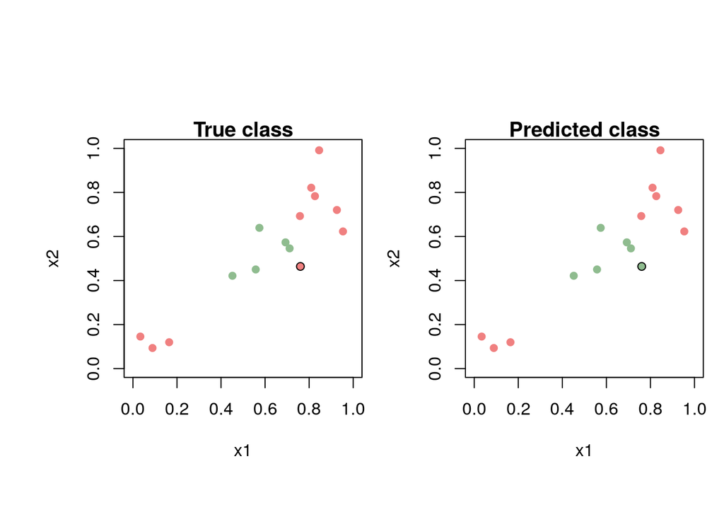

```r
table(predict = ypred_kernel, truth = test3[, 3])
```

```
##        truth
## predict -1 1
##      -1  9 0
##      1   1 5
```

Only one seed is misclassified.

## Tuning parameter example

Heart data - predict heart disease from $p=13$ predictors.

Training errors as ROC and AUC.

$~$

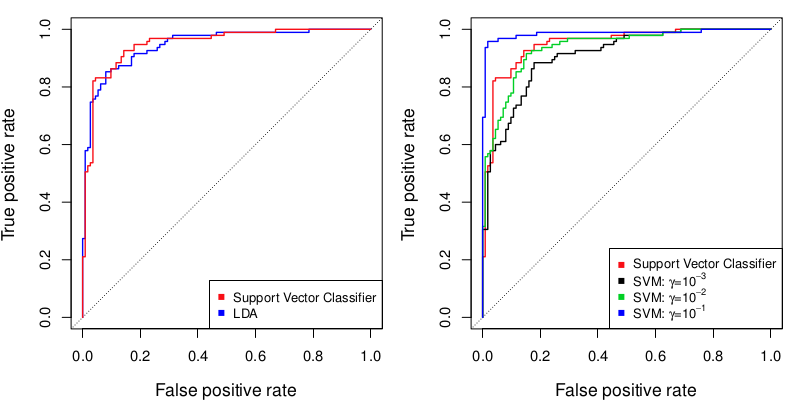

ISLR Figure 9.10

$~$

**Q**: How are the ROC curves formed?

Heart data - test error.

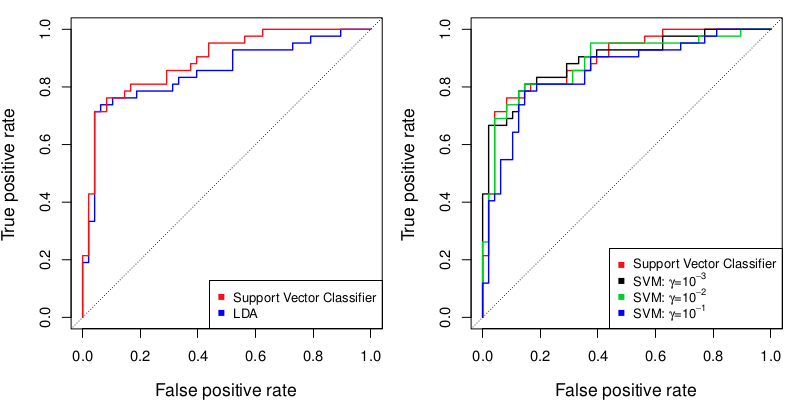

ISLR Figure 9.11

# Extensions

## More than two classes

$~$

# Comparisons: SVM and logistic regression

It is possible to write the optimization problem for the support vector classifier as a “loss”+“penalty”:

$$\text{minimize}_{\boldsymbol \beta}
\left\{ \underbrace{\sum_{i=1}^n \max(0,1-y_i f({\boldsymbol
x}_i))}_{=L(\boldsymbol x, \boldsymbol{y},\boldsymbol\beta)}+
\underbrace{\lambda \sum_{j=1}^p \beta_j^2}_{\text{Penalty}}
\right\}$$

Interestingly, the loss functions for a support-vector classifier with $f(X)=\beta_0 + \beta_1X_1 +\ldots + \beta_pX_p$ and for logistic regression using the same set of predictors *look very similar*:

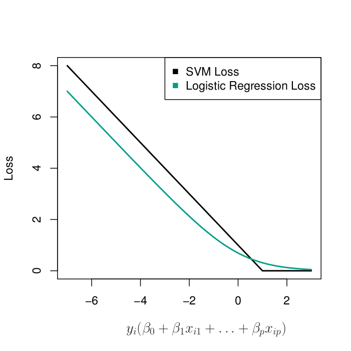

ISLR Figure 9.12: hinge loss - loss 0 for observations on the correct side of the margin

**Hinge loss:**
$$\max(0,1-y_if({\boldsymbol x}_i))$$

- For comparison a logistic regression loss function would be (binomial deviance with $-1,1$ coding of $y$)
  $$\log(1+\exp(-y_i f({\boldsymbol x}_i)))\ .$$
- In logistic regression all observations contribute weighted by $p_i(1-p_i)$ (where $p_i$ is probability for class 1), that fade smoothly with distance to the decision boundary
- Of course, it is possible to extend the logistic regression to include non-linear terms, and *also a ridge penalty*.

## When to use SVM?

$~$

- If classes are nearly separable SVM will perform better than logistic regression. (Also LDA will perform better than logistic regression; what is the problem with logistic regression?)
- Otherwise, a ridge penalty version of logistic regression is **very** similar to SVM, and logistic regression will also give you probabilities for each class.
- If class boundaries are non-linear then SVM is more popular, but *kernel versions of logistic regression* are also possible, but more computationally expensive (and traditionally less used).
- Drawbacks of SVMs: No feature selection, no probabilities, thus in general interpretability is difficult.

# Summing up

- We use methods from computer science, not probability models, but it also looks for a separating hyperplane in (an extended) feature space in the classification setting.
- SVM is a widely successful and a “must have tool”.
- Interpretation of SVM: all features are included and maybe not so easy to interpret (remember ridge-type penalty does not shrink to zero).
- The budget must be chosen wisely, and a bad choice can lead to overfitting.
- Not so easy to get class probabilites from SVM (what is done is actually to fit a logistic regression after fitting SVM).

# Further reading

- [Videoes on YouTube by the authors of ISL, Chapter 9](https://www.youtube.com/playlist?list=PL5-da3qGB5IDl6MkmovVdZwyYOhpCxo5o), and corresponding [slides](https://lagunita.stanford.edu/c4x/HumanitiesScience/StatLearning/asset/svm.pdf)
- [Solutions to exercises in the book, chapter 9](https://rpubs.com/ppaquay/65566)
- [Chapters 12.1-12.3](https://web.stanford.edu/~hastie/ElemStatLearn) in Hastie, Tibshirani, and Friedman (2009).
- [Chapter 19 (Support-Vector Machines and Kernel Methods)](https://web.stanford.edu/~hastie/CASI/) in Efron and Hastie (2016).

# References

Efron, Bradley, and Trevor Hastie. 2016. *Computer Age Statistical Inference - Algorithms, Evidence, and Data Science*. Cambridge University Press.

Hastie, Trevor, Robert Tibshirani, and Jerome Friedman. 2009. *The Elements of Statistical Learning*. 2nd ed. Vol. 1. Springer series in statistics New York.

James, G., D. Witten, T. Hastie, and R. Tibshirani. 2013. *An Introduction to Statistical Learning with Applications in r*. New York: Springer.